# Evaporation Models

Connor Brogan

April 13, 2018

## Summary

This markdown file should step through the evaporation models that I have coded up in R thus far for the state of Virginia. The code draws in annual temperature data from PRISM between 1955-1970 and then calculates rasters with long-term averages of average temperature, minimum temperature, and maximum temperature. Rasters are clipped to an arbitrary bounding box that is located in the area around Virginia and then reprojected to the EPSG 4236 coordinate system. The waterbody dataset (available on the drive) is then read in and projected into UTM zone 17N projection. In doing so, area can be recalculated for the waterbodies. A point dataset for waterbody center of mass is developed and used to extract minimum, maximum, and average temperature. These values are added back to the original polygons and used to drive evaporation models. Additional calculations are requrired to produce values for extraterstrial radiation, daylight length, and latent heat of evaporation. Data can be wrote out as a shapefile and imported to GIS for interpolation (i.e. kriging), which I haven’t looked into in R yet.

## Data Initialization

The following three libraries are used in this analysis.**rgeos** is a useful package in spatial analysis and allows for quick manipulation of polygons to produce center-of-mass centroid points. It further contains useful tools for area calculations, intersections, projects, and other spaital processes not used here. **rgdal** is a useful spatial analysis package that allows R to interface with ESRI geodatabases and file types. In addition, it contains many useful functions in handling data projections, clipping, and calculations. Finally, **raster** contains functions that make it easier to handle rasters, allowing users to manipulate raster data directly. It also allows for the creation of *raster stacks* and *bricks* that are convenient in storing multiple rasters (similar to a *list* of data frames).

```r
library(rgeos)
library(rgdal)
library(raster)
```

The next lines produce a vector of numeric monthly abbreviations used by PRISM and accesses a pre-downloaded geodatabase containing a polygon feature class of the state boundary and a bounding box for the analysis. This box was created prior to the analysis in ArcGIS. The bounding box was projected into EPSG 4326, as already used by the state boundary. Be sure to set your file path, as appropriate.

```r
my.filepath <- 'C:/Users/connorb5/Desktop/GitHub/cbp_wsm/evap/'
m<-c('01','02','03','04','05','06','07','08','09','10','11','12')
VA<-readOGR(paste(my.filepath,'EvapInputs.gdb',sep=""),layer="VA")
BB<-readOGR(paste(my.filepath,'EvapInputs.gdb',sep=""),layer="BoundingBox")
BB<-spTransform(BB,CRS="+proj=longlat +ellps=GRS80 +towgs84=0,0,0,0,0,0,0 +no_defs")
```

```r
crs(VA)
```

```
## CRS arguments:
##  +proj=longlat +ellps=GRS80 +towgs84=0,0,0,0,0,0,0 +no_defs
```

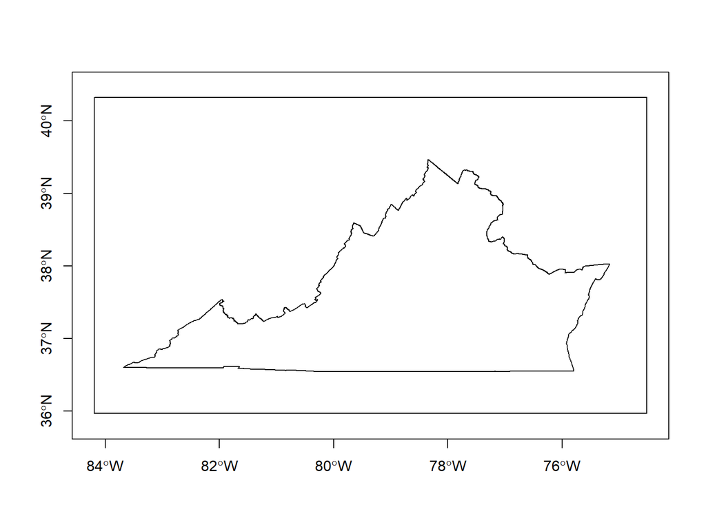

The bounding box can also be creted within R, by inputting the desired coordinates below. Be sure to project the new polygon into the same reference system as the state boundary. Coordinates should be input as: (x_min, y_min), (x_max, y_min), (x_max, y_max), (x_min, y_max), (x_min, y_min) using a matrix and converting it to a spatial polygon using the *sp* library (which is a subcomponent of *rgdal*).

```r
library(sp)
x_min<--74
x_max<--85
y_min<-35
y_max<-42
coords = matrix(c(x_min,y_min,x_max,y_min,x_max,y_max,x_min,y_max,x_min,y_min),ncol = 2, byrow = TRUE)
BB = Polygon(coords)
BB = SpatialPolygons(list(Polygons(list(BB), ID = "a")), proj4string=CRS("+proj=longlat +ellps=GRS80 +towgs84=0,0,0,0,0,0,0 +no_defs"))
```

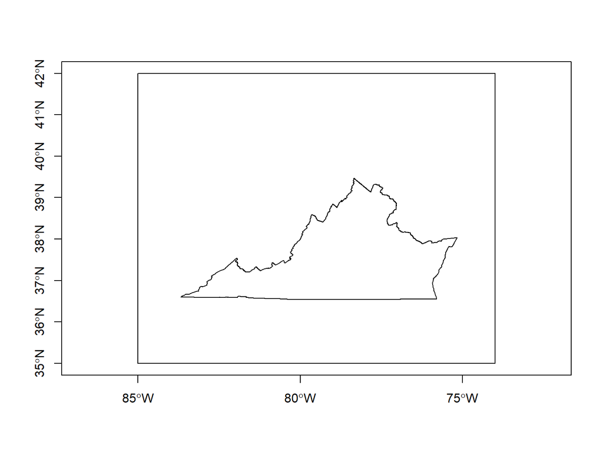

## Mean Monthly Raster Creation

The next primary component of the code is the reformatting of PRISM data to produce long-term averaged values for maximum temperature, minimum temperature, and mean temperature for the boudning box. The PRISM data can be obtained automatically in R, but was here downloaded manually [here](http://prism.oregonstate.edu/historical/) using the “Download All Historical Data (.bil)” option at the bottom left. Create a folder with three subdirectories “TMean”, “TMax”, and “TMin” to hold data pertaining to each of the three variables respectivley. Data can be downloaded from PRISM in R using the following commands after setting the paths to the necessary folders as designating a year range. **NOTE** Data can only be downloaded once a day. Repeated requests may result in IP blocking:

```r
yr<-as.character(seq(1955,1970))
pathTMean<- paste(my.filepath,'PRISM\\TMean',sep="")
pathTMax <- paste(my.filepath,'PRISM\\TMax',sep="")
pathTMin <- paste(my.filepath,'PRISM\\TMin',sep="")
for(i in 1:length(yr)){
  temp<-tempfile()
  download.file(paste0("http://services.nacse.org/prism/data/public/4km/tmean/",yr[i]),temp,mode='wb')
  unzip(zipfile=temp,exdir=pathTMean)

  temp<-tempfile()
  download.file(paste0("http://services.nacse.org/prism/data/public/4km/tmax/",yr[i]),temp,mode='wb')
  unzip(temp,exdir=pathTMax)

  temp<-tempfile()
  download.file(paste0("http://services.nacse.org/prism/data/public/4km/tmin/",yr[i]),temp,mode='wb')
  unzip(temp,exdir=pathTMin)
}
```

Once data has been downloaded, the code changes the working directory to the created folder containing all of the PRISM mean temperature data, where it creates a new folder called “Monthly Averages” to store output rasters.

```r
setwd(paste(my.filepath,"PRISM\\TMean",sep=""))
dir.create('Monthly Averages')
```

It searches the directory for all file containing bil.bil as the extension, which is how PRISM designates its raster files. It then creates a list of file names in vector *r* (for raster) for the PRISM rasters within the years of interest (only necessary if all historic data was downloaded). This will compile the PRISM rasters for each indiviudal month of the year for every year of interest.

```r
setwd(paste(my.filepath,"PRISM\\TMean",sep=""))
files<-list.files()
files<-files[grep('bil.bil$',files)]
yr<-as.character(seq(1955,1970))
r<-character()
for (i in 1:length(yr)){
  case<-files[grep(yr[i],files)]
  r<-c(case,r)
}
```

```
## [1] "PRISM_tmean_stable_4kmM2_197001_bil.bil"
## [2] "PRISM_tmean_stable_4kmM2_197002_bil.bil"
## [3] "PRISM_tmean_stable_4kmM2_197003_bil.bil"
## [4] "PRISM_tmean_stable_4kmM2_197004_bil.bil"
## [5] "PRISM_tmean_stable_4kmM2_197005_bil.bil"
## [6] "PRISM_tmean_stable_4kmM2_197006_bil.bil"
```

The script then searches for each filename within the directory matching those in the vector *r* for a given month in the created monthly abbreviations vector *m*. It finds the raster files and stores their names in the vector *case*. One by one, it loads rasters from *case* using the **raster** package and projects them, extracts them from the national scale to the bounding box extent, and then adds them to a raster stack for that month. As the loop finishes, the mean value of the rasterstack is stored in raster “MeanTempYY” as the long-term temperature average of month YY. This raster is written out to the created “Monthly Average” directory as a *.tiff* file. This process is repeated for minimum and maximum temperature. Users MUST change the directories where the script searches for PRISM data!

```r
for (j in 1:length(m)){
  print(paste("Month ",j," of ",length(m),sep=""))
  case<-grep(paste0(m[j],'_bil.bil$'),r)
  rstack<-stack()
  for (i in 1:length(case)){
    print(paste("case ",i," of ",length(case),sep=""))
    test<-raster(r[case[i]])
    test<-projectRaster(test,crs=proj4string(BB))
    testclip<-mask(test,BB)
    rstack<-addLayer(rstack,testclip)
  }
  assign(paste0('MeanTemp_',m[j]),mean(rstack))
  writeRaster(mean(rstack), filename=paste0('Monthly Averages/MeanTemp',m[j],'.tiff'))
}
```

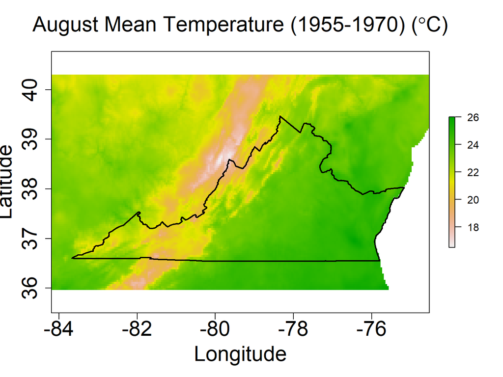

## Solar Radiation Calculations

Evapotranspiration can be estimated through the Hargreaves equation as presented by (see Lu et al. “A Comparison of Six Potential Evapotranspiration Methods for Regional Use in the Southeastern United States” in 2005 JAWRA):

$\large PET = \frac{C_1*R_a*(TD)^{0.5}*(T_M+C_2)}{\lambda}$

Where:  
$PET$ = Potential Evapotranspiration (mm/day)  
$\lambda$ = Latent Heat of Evaporation (MJ/kg)  
$R_a$ = Extraterrestrial Solar Radiation (MJ/m<sup>2</sup>/day)  
$TD$ = Difference Betwen Monthly Maximum and Minimum Temperature ($^\circ$C)  
$T_M$ = Average Monthly Temperature ($^\circ$C)  
$C_1$ = Coefficient commonly set to 0.0023 (used here) or 0.0134  
$C_2$ = Coefficient commonly set to 17.8 (used here)

Where:  
$R_a$ = Extraterrestrial Solar Radiation (MJ/m<sup>2</sup>/day)  
$G_{sc}$ = The Global Solar Radiation Constant (assumed 0.0820 MJ/m<sup>2</sup>/min)  
$d_r$ = Inverse relative distance from the Sun to the Earth  
$\omega_s$ = Sunset Hour Angle (radians)  
$\phi$ = Latitude (radians)  
$\sigma$ = Solar Desimation (radians)  
In turn, the inverse relative distance Earth-Sun can be estimated from:

$\large d_r=1+0.033cos(\frac{2\pi}{365}J)$

Where $J$ = Julian Day (1 for January 1<sup>st</sup>, 365/366 for December 31<sup>st</sup>)  
Following this, solar decimation can be estimated as:

$\large \sigma=0.409sin(\frac{2\pi}{365}J-1.39)$

Finally, sunset hour can be found using:

```r
WB<-readOGR(paste(my.filepath,'EvapInputs.gdb',sep=""),layer="Waterbodies")
WB<-spTransform(WB,'+proj=utm +zone=17 +ellps=GRS80 +datum=NAD83 +units=m +no_defs')
WB@data$FID<-1:length(WB@data$COMID)
WB@data$AreaRcalc<-gArea(WB,byid=T)
WB<-spTransform(WB,CRS="+proj=longlat +ellps=GRS80 +towgs84=0,0,0,0,0,0,0 +no_defs")
WBCenter<-gCentroid(WB,byid=T,id=WB@data$FID)
```

Extraterrestrial solar radiation calculations are begun by creating a vector *diy* of Julian day of the year. This is passed in two subsequent calculations to produce inverse distance from the sun (*distFsun*) and solar decimation (*sigma*). These are calculated in vecotrs of length 365 for each day of the year.

```r
diy<-seq(1,365)
distFsun<-1+0.033*cos(2*pi*diy/365)
sigma<-0.409*sin(2*pi*diy/365-1.39)
```

Mean extraterrestiral radiation is then calculated for each month following the FAO equations above.

```r
for (i in 1:length(WB@data$FID)){
  print(paste("Mean extraterrestrial radiation calc for WB ",i," of ",length(WB@data$FID),sep=""))
  lat<-as.numeric(WBCenter@coords[i,2])*pi/180
  sunsethour<-acos(-tan(sigma)*tan(lat))
  Ra<-(25*60*0.0820/pi)*distFsun*(sunsethour*sin(lat)*sin(sigma)+cos(lat)*cos(sigma)*sin(sunsethour))
  WB@data$JanRa[i]<-mean(Ra[1:31])
  WB@data$FebRa[i]<-mean(Ra[32:59])
  WB@data$MarRa[i]<-mean(Ra[60:90])
  WB@data$AprRa[i]<-mean(Ra[91:120])
  WB@data$MayRa[i]<-mean(Ra[121:151])
  WB@data$JunRa[i]<-mean(Ra[152:181])
  WB@data$JulRa[i]<-mean(Ra[182:212])
  WB@data$AugRa[i]<-mean(Ra[213:243])
  WB@data$SepRa[i]<-mean(Ra[244:273])
  WB@data$OctRa[i]<-mean(Ra[274:304])
  WB@data$NovRa[i]<-mean(Ra[305:334])
  WB@data$DecRa[i]<-mean(Ra[335:365])
}
```

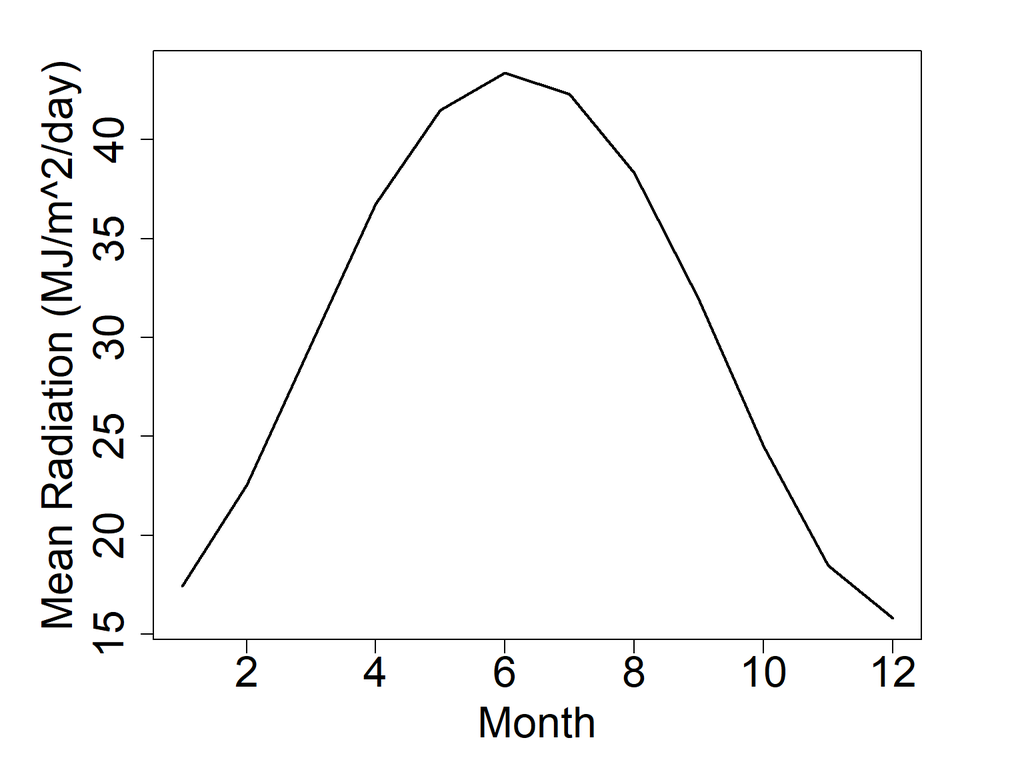

## Hargreaves Evapotranspiration Estimation

Evapotranspiration can be estimated through the Hargreaves equation as presented by (see Lu et al. “A Comparison of Six Potential Evapotranspiration Methods for Regional Use in the Southeastern United States” in 2005 JAWRA):

$\large PET = \frac{C_1*R_a*(TD)^{0.5}*(T_M+C_2)}{\lambda}$

Now all compponents of the Hargreaves equation are available to estimate evaporation off of our waterbodies. By using the waterbody centroid, we can extract values for the maximum - minimum temperature and the mean temperature from the long-term averaged rasters developed earlier. This can be accomplished using the extract function within the **raster** library, which takes data from the raster based on the location of an input point or polygon. Here I have demonstrated the process at the waterbody center. Although the function can handle input polygons, this will take a long time to run and produce using our 73,000+ waterbodies.

```r
WB@data$JanDiffT<-extract(MaxTemp_01,WBCenter)-extract(MinTemp_01,WBCenter)
WB@data$JanMeanT<-extract(MeanTemp_01,WBCenter)
WB@data$FebDiffT<-extract(MaxTemp_02,WBCenter)-extract(MinTemp_02,WBCenter)
WB@data$FebMeanT<-extract(MeanTemp_02,WBCenter)
WB@data$MarDiffT<-extract(MaxTemp_03,WBCenter)-extract(MinTemp_03,WBCenter)
WB@data$MarMeanT<-extract(MeanTemp_03,WBCenter)
WB@data$AprDiffT<-extract(MaxTemp_04,WBCenter)-extract(MinTemp_04,WBCenter)
WB@data$AprMeanT<-extract(MeanTemp_04,WBCenter)
WB@data$MayDiffT<-extract(MaxTemp_05,WBCenter)-extract(MinTemp_05,WBCenter)
WB@data$MayMeanT<-extract(MeanTemp_05,WBCenter)
WB@data$JunDiffT<-extract(MaxTemp_06,WBCenter)-extract(MinTemp_06,WBCenter)
WB@data$JunMeanT<-extract(MeanTemp_06,WBCenter)
WB@data$JulDiffT<-extract(MaxTemp_07,WBCenter)-extract(MinTemp_07,WBCenter)
WB@data$JulMeanT<-extract(MeanTemp_07,WBCenter)
WB@data$AugDiffT<-extract(MaxTemp_08,WBCenter)-extract(MinTemp_08,WBCenter)
WB@data$AugMeanT<-extract(MeanTemp_08,WBCenter)
WB@data$SepDiffT<-extract(MaxTemp_09,WBCenter)-extract(MinTemp_09,WBCenter)
WB@data$SepMeanT<-extract(MeanTemp_09,WBCenter)
WB@data$OctDiffT<-extract(MaxTemp_10,WBCenter)-extract(MinTemp_10,WBCenter)
WB@data$OctMeanT<-extract(MeanTemp_10,WBCenter)
WB@data$NovDiffT<-extract(MaxTemp_11,WBCenter)-extract(MinTemp_11,WBCenter)
WB@data$NovMeanT<-extract(MeanTemp_11,WBCenter)
WB@data$DecDiffT<-extract(MaxTemp_12,WBCenter)-extract(MinTemp_12,WBCenter)
WB@data$DecMeanT<-extract(MeanTemp_12,WBCenter)
```

Now, the Hargreaves equation can be used to estimate monthly evaporation at each waterbody. Latent heat can be estimated by the equations presented by Marvin jensen and Richard Allen in [“Evaporation, Evaportranspiration, and Irrigation Water Requirements”](https://ascelibrary.org/doi/pdf/10.1061/9780784414057) in the ASCE Manuals and Reports on Engineering Practive No. 70. Latent heat is commonly approximated as 2.45 MJ/kg but is here estimated as:

$\large \lambda=2.501-0.002361*T_M$

```r
c1<-0.0023
c2<-17.8
WB@data$JanHarg<-c1*WB@data$JanRa*sqrt(WB@data$JanDiffT)*(WB@data$JanMeanT+c2)/(2.501-.002361*WB@data$JanMeanT)
WB@data$FebHarg<-c1*WB@data$FebRa*sqrt(WB@data$FebDiffT)*(WB@data$FebMeanT+c2)/(2.501-.002361*WB@data$FebMeanT)
WB@data$MarHarg<-c1*WB@data$MarRa*sqrt(WB@data$MarDiffT)*(WB@data$MarMeanT+c2)/(2.501-.002361*WB@data$MarMeanT)
WB@data$AprHarg<-c1*WB@data$AprRa*sqrt(WB@data$AprDiffT)*(WB@data$AprMeanT+c2)/(2.501-.002361*WB@data$AprMeanT)
WB@data$MayHarg<-c1*WB@data$MayRa*sqrt(WB@data$MayDiffT)*(WB@data$MayMeanT+c2)/(2.501-.002361*WB@data$MayMeanT)
WB@data$JunHarg<-c1*WB@data$JunRa*sqrt(WB@data$JunDiffT)*(WB@data$JunMeanT+c2)/(2.501-.002361*WB@data$JunMeanT)
WB@data$JulHarg<-c1*WB@data$JulRa*sqrt(WB@data$JulDiffT)*(WB@data$JulMeanT+c2)/(2.501-.002361*WB@data$JulMeanT)
WB@data$AugHarg<-c1*WB@data$AugRa*sqrt(WB@data$AugDiffT)*(WB@data$AugMeanT+c2)/(2.501-.002361*WB@data$AugMeanT)
WB@data$SepHarg<-c1*WB@data$SepRa*sqrt(WB@data$SepDiffT)*(WB@data$SepMeanT+c2)/(2.501-.002361*WB@data$SepMeanT)
WB@data$OctHarg<-c1*WB@data$OctRa*sqrt(WB@data$OctDiffT)*(WB@data$OctMeanT+c2)/(2.501-.002361*WB@data$OctMeanT)
WB@data$NovHarg<-c1*WB@data$NovRa*sqrt(WB@data$NovDiffT)*(WB@data$NovMeanT+c2)/(2.501-.002361*WB@data$NovMeanT)
WB@data$DecHarg<-c1*WB@data$DecRa*sqrt(WB@data$DecDiffT)*(WB@data$DecMeanT+c2)/(2.501-.002361*WB@data$DecMeanT)
```

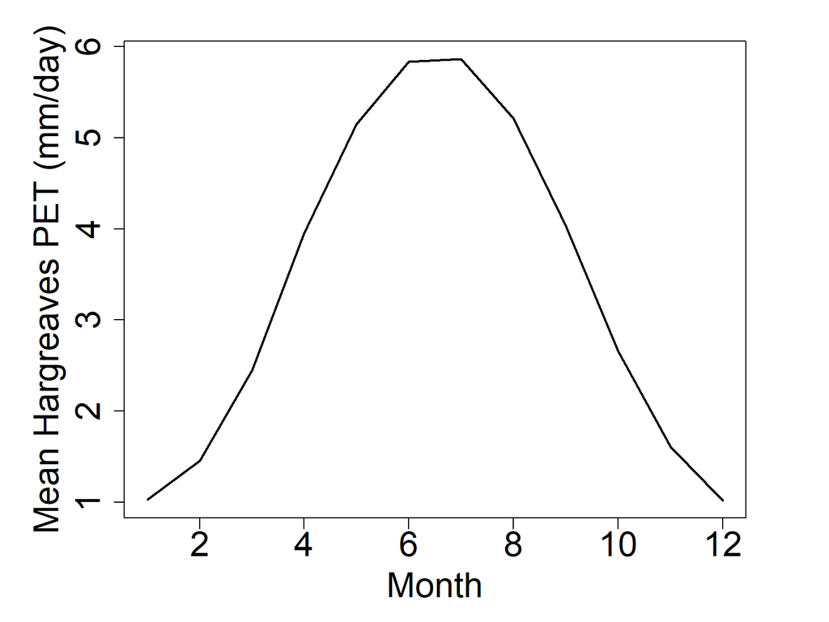

## Thornthwaite Evapotranspiration Estimation

This script will also approximate evaporation at each waterbody using the Thornthwaite method (as used by the Office of Climateology for the state). This model can also be seen in e Lu et al. “A Comparison of Six Potential Evapotranspiration Methods for Regional Use in the Southeastern United States” in 2005 JAWRA. The Thornthwaite model takes the form (assumes $PET=0$ if $T_M<0$):

$\large PET=\frac{10C}{12D}L_d(\frac{10T_M}{I})^a$

Where:  
$PET$ = Potential Evapotranspiration (mm/day)  
$D$ = Number Days in the Month  
$L_d$ = Time Between Sunrise and Sunset (hours)  
$T_M$ = Average Monthly Temperature ($^\circ$C)  
$I$ = The Thornthwaite Temperature Index  
$a$ = Coefficient commonly set as a function of $I$  
$C$ = Coefficient commonly set to 1.6  
The Thornthwaite Temperature Index can then be written as follows ($I=0$ if $T_M<0$):

$\large \sum_{i=1}^{12}(\frac{T_{M,i}}{5})^{1.514}$

Then, the coefficient $a$ was derived as:

$\large a=0.000000675I^3-0.0000771I^2+0.01791I+0.49239$

Finally, the time between sunrise and sunset may be written as the following and is thus dependent on sunset hour:

$\large L_d=\frac{24\omega_s}{pi}$

The following piece of code calculates the mean number of sunlight hours for each day of the year. It looks at each waterbody indiviudally and uses their waterbody centroid latitude to drive sunset hour calculations and subsequently sunlight hours.

```r
for (i in 1:length(WB@data$FID)){
  print(paste("Avg mo daylight hrs calc for WB ",i," of ",length(WB@data$FID),sep=""))
  lat<-as.numeric(WBCenter@coords[i,2])*pi/180
  sunsethour<-acos(-tan(sigma)*tan(lat))
  Ld<-24*sunsethour/pi
  Ra<-(25*60*0.0820/pi)*distFsun*(sunsethour*sin(lat)*sin(sigma)+cos(lat)*cos(sigma)*sin(sunsethour))
  WB@data$JanLd[i]<-mean(Ld[1:31])
  WB@data$FebLd[i]<-mean(Ld[32:59])
  WB@data$MarLd[i]<-mean(Ld[60:90])
  WB@data$AprLd[i]<-mean(Ld[91:120])
  WB@data$MayLd[i]<-mean(Ld[121:151])
  WB@data$JunLd[i]<-mean(Ld[152:181])
  WB@data$JulLd[i]<-mean(Ld[182:212])
  WB@data$AugLd[i]<-mean(Ld[213:243])
  WB@data$SepLd[i]<-mean(Ld[244:273])
  WB@data$OctLd[i]<-mean(Ld[274:304])
  WB@data$NovLd[i]<-mean(Ld[305:334])
  WB@data$DecLd[i]<-mean(Ld[335:365])
}
```

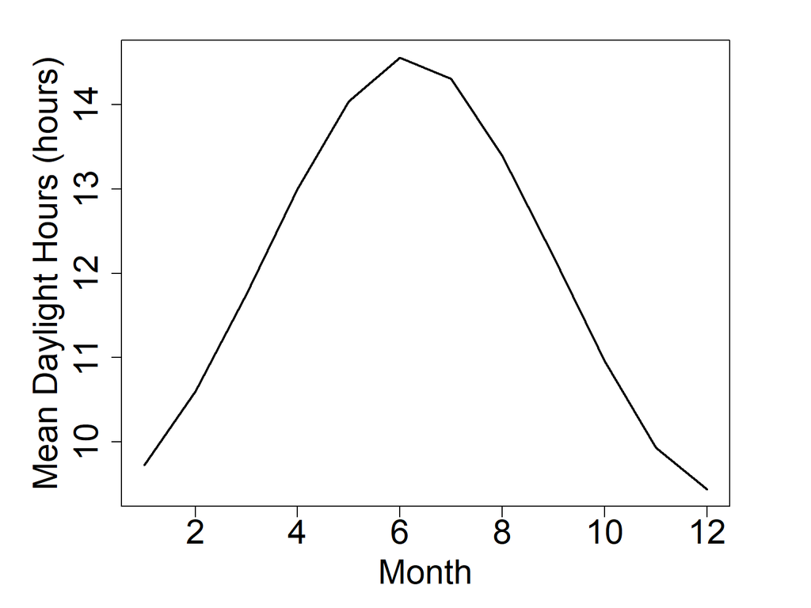

The code then creates a function *ThornI* that it uses to calculate the Thornthwaite temperature index using the extracted mean temperature values contained within the waterbody centroids. This function is design to check for temperatures below freezing and set PET accordingly. Otherwise, it calculates the index as directed above for each waterbody.

```r
ThornI<-function(meanT){
  if(meanT<0){
    out<-0
  }else{
    out<-(meanT/5)^1.514
  }
  return(out)
}
```

The function is used to calculate the temperature index at each waterbody for each month by passing in a mean monthly temperature. The coefficietn $a$ is then calculated using the index at each waterbody. Typical values for $I$ range between 0 to 160 and those for $a$ between 0 and 4.5 (per Thornthwaite 1948 in “An Approach toward a Rational Classification of Climate” in Geographical Review)

```r
for (i in 1:length(WB@data$FID)){
  print(paste("Thornthwaite temperature index calc for WB ",i," of ",length(WB@data$FID),sep=""))
  Jan<-ThornI(WB@data$JanMeanT[i])
  Feb<-ThornI(WB@data$FebMeanT[i])
  Mar<-ThornI(WB@data$MarMeanT[i])
  Apr<-ThornI(WB@data$AprMeanT[i])
  May<-ThornI(WB@data$MayMeanT[i])
  Jun<-ThornI(WB@data$JunMeanT[i])
  Jul<-ThornI(WB@data$JulMeanT[i])
  Aug<-ThornI(WB@data$AugMeanT[i])
  Sep<-ThornI(WB@data$SepMeanT[i])
  Oct<-ThornI(WB@data$OctMeanT[i])
  Nov<-ThornI(WB@data$NovMeanT[i])
  Dec<-ThornI(WB@data$DecMeanT[i])
  WB@data$I[i]<-Jan+Feb+Mar+Apr+May+Jun+Jul+Aug+Sep+Oct+Nov+Dec
}
WB@data$a<-(0.000000675*WB@data$I^3)-(0.0000771*WB@data$I^2)+(0.01791*WB@data$I)+0.49239
```

The Thornthwaite model can then be calculated with the Thornthwaite Model. Note how evaporation is set to 0 where values of $T_M<0$ created *NA* values:

$\large PET=\frac{10C}{12D}L_d(\frac{10T_M}{I})^a$

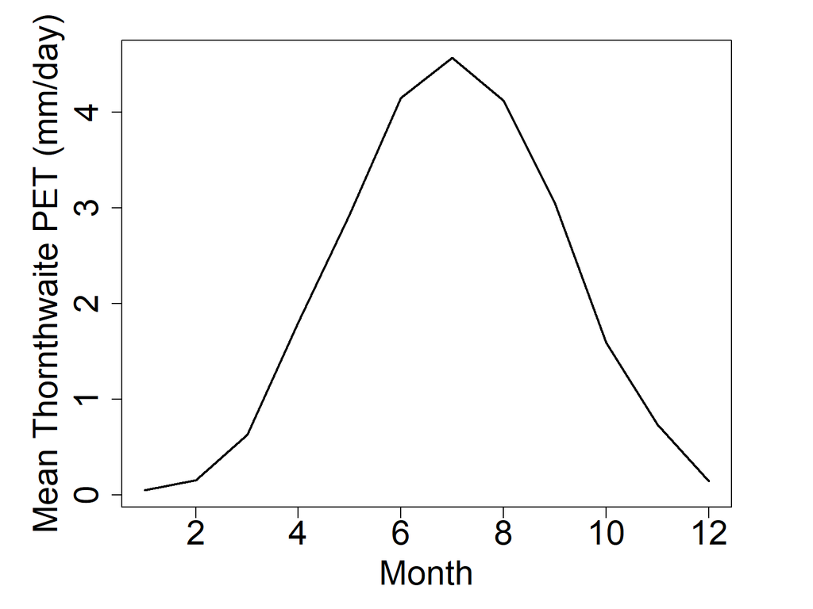

```r
c<-16
WB@data$JanThorn<-(c*WB@data$JanLd*(10*WB@data$JanMeanT/WB@data$I)^WB@data$a)/31/12
WB@data$JanThorn[is.na(WB@data$JanThorn)]<-0
WB@data$FebThorn<-(c*WB@data$FebLd*(10*WB@data$FebMeanT/WB@data$I)^WB@data$a)/28/12
WB@data$FebThorn[is.na(WB@data$FebThorn)]<-0
WB@data$MarThorn<-(c*WB@data$MarLd*(10*WB@data$MarMeanT/WB@data$I)^WB@data$a)/31/12
WB@data$MarThorn[is.na(WB@data$MarThorn)]<-0
WB@data$AprThorn<-(c*WB@data$AprLd*(10*WB@data$AprMeanT/WB@data$I)^WB@data$a)/30/12
WB@data$AprThorn[is.na(WB@data$AprThorn)]<-0
WB@data$MayThorn<-(c*WB@data$MayLd*(10*WB@data$MayMeanT/WB@data$I)^WB@data$a)/31/12
WB@data$MayThorn[is.na(WB@data$MayThorn)]<-0
WB@data$JunThorn<-(c*WB@data$JunLd*(10*WB@data$JunMeanT/WB@data$I)^WB@data$a)/30/12
WB@data$JunThorn[is.na(WB@data$JunThorn)]<-0
WB@data$JulThorn<-(c*WB@data$JulLd*(10*WB@data$JulMeanT/WB@data$I)^WB@data$a)/31/12
WB@data$JulThorn[is.na(WB@data$JulThorn)]<-0
WB@data$AugThorn<-(c*WB@data$AugLd*(10*WB@data$AugMeanT/WB@data$I)^WB@data$a)/31/12
WB@data$AugThorn[is.na(WB@data$AugThorn)]<-0
WB@data$SepThorn<-(c*WB@data$SepLd*(10*WB@data$SepMeanT/WB@data$I)^WB@data$a)/30/12
WB@data$SepThorn[is.na(WB@data$SepThorn)]<-0
WB@data$OctThorn<-(c*WB@data$OctLd*(10*WB@data$OctMeanT/WB@data$I)^WB@data$a)/31/12
WB@data$OctThorn[is.na(WB@data$OctThorn)]<-0
WB@data$NovThorn<-(c*WB@data$NovLd*(10*WB@data$NovMeanT/WB@data$I)^WB@data$a)/30/12
WB@data$NovThorn[is.na(WB@data$NovThorn)]<-0
WB@data$DecThorn<-(c*WB@data$DecLd*(10*WB@data$DecMeanT/WB@data$I)^WB@data$a)/31/12
WB@data$DecThorn[is.na(WB@data$DecThorn)]<-0
```

## Analysis

Although this is likely going to be a growing component to the code, this last section finds annual evaporation rates at each waterbody and multiplies by the calculated waterbody area to produce an estimate for evaporation in BGY. These are summed below. These can be exported to GIS with the **rgdal** package and used to create interpolated maps of state-wide evaporation.

```r
evapH<-numeric()
evapT<-numeric()
for (i in 1:length(WB@data$FID)){
  print(paste("Evap BGY estimation for WB ",i," of ",length(WB@data$FID),sep=""))
  evapH[i]<-sum(WB@data[i,grep('Harg',colnames(WB@data))]*c(31,28,31,30,31,30,31,31,30,31,30,31))
  evapT[i]<-sum(WB@data[i,grep('Thorn',colnames(WB@data))]*c(31,28,31,30,31,30,31,31,30,31,30,31))
}
WB@data$AnnualHrg_mmpyr<-evapH
WB@data$AnnualHrg_BGY<-WB@data$AreaRcalc*(evapH/1000)*264.1721/1000000000
WB@data$AnnualThrn_mmpyr<-evapT
WB@data$AnnualThrn_BGY<-WB@data$AreaRcalc*(evapT/1000)*264.1721/1000000000
```

| Method | Evaporation (BGY) |
| --- | --- |
| Hargreaves | 314 |
| Thornthwaite | 188 |
| Original | 255 |

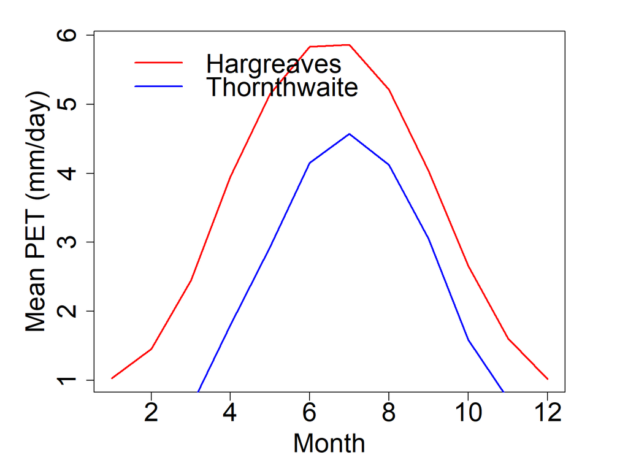

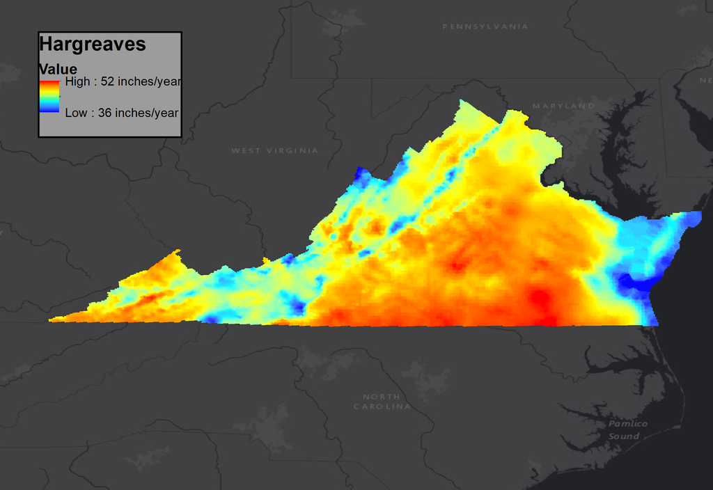

Hargreaves Approximation

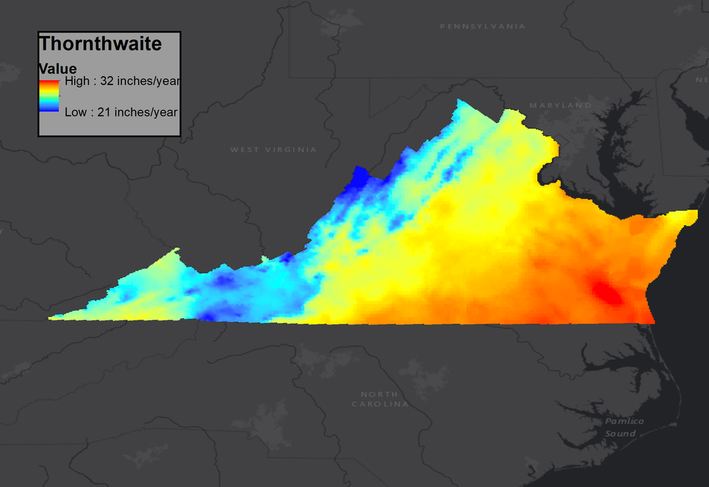

Thornthwaite Approximation

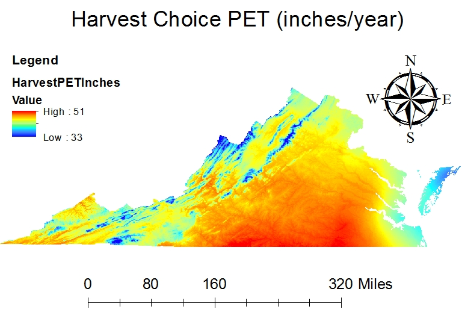

Harvest Choice High Res Hargreaves Approx. (for comparison)